# Tugas Kelompok Praktikum 1

Author

Kelompok 11

# Tim Kelompok

**Penyusun**

| Wira Adiguna Sutawa | M0501261029 |
| --- | --- |
| Hairatun Hisanun | M0501261016 |
| Azadillah Aulia Ramadhani | M0501261064 |

# SOAL 1

Pembersihan Data Mahasiswa

Diberikan dataset mentah pada Tabel 1 berikut.

Tabel 1. Dataset Nilai Mahasiswa

| Nama | Matematika | Statistika | Umur |
| --- | --- | --- | --- |
| Andi | 80 | 85 | 21 |
| Budi | 90 | 88 | 20 |
| Citra | NA | 78 | 22 |
| Dewi | 75 | - | 21 |
| Andi | 80 | 85 | 21 |

### 1. Data frame

Buat data frame bernama `nilai_raw` secara manual di R berdasarkan Tabel 1.

```r
nilai_raw <- data.frame(
  Nama = c("Andi", "Budi", "Citra", "Dewi", "Andi"),
  Matematika = c(80, 90, NA, 75, 80),
  Statistika = c(85, 88, 78, "-", 85),
  Umur = c(21, 20, 22, 21, 21)
)

nilai_raw
```

| Nama | Matematika | Statistika | Umur |
| --- | --- | --- | --- |
| Andi | 80 | 85 | 21 |
| Budi | 90 | 88 | 20 |
| Citra | NA | 78 | 22 |
| Dewi | 75 | - | 21 |
| Andi | 80 | 85 | 21 |

### 2. Identifikasi

Identifikasi nilai yang hilang pada dataset secara sistematis. Ubah tanda hubung (`"-"`) pada nilai Statistika milik Dewi menjadi nilai hilang standar R, yaitu `NA`.

**Caution**

Penyelesaian

```r
is.na(nilai_raw)
```

```
      Nama Matematika Statistika  Umur
[1,] FALSE      FALSE      FALSE FALSE
[2,] FALSE      FALSE      FALSE FALSE
[3,] FALSE       TRUE      FALSE FALSE
[4,] FALSE      FALSE      FALSE FALSE
[5,] FALSE      FALSE      FALSE FALSE
```

```r
sum(is.na(nilai_raw))
```

```
[1] 1
```

```r
nilai_raw$Statistika[nilai_raw$Statistika == "-"] <- NA
nilai_raw$Statistika <- as.numeric(nilai_raw$Statistika)
```

**Note**

### 3. Imputasi Rata-rata

Lakukan imputasi terhadap nilai `Statistika` yang kosong menggunakan rata-rata nilai Statistika mahasiswa lainnya yang tersedia.

Penyelesaian

biar data menjadi bersih kami imputasi juga nilai matematika.

```r
nilai_raw$Statistika[is.na(nilai_raw$Statistika)] <- mean(nilai_raw$Statistika, na.rm = TRUE)
nilai_raw$Matematika[is.na(nilai_raw$Matematika)] <- mean(nilai_raw$Matematika, na.rm = TRUE)

nilai_raw
```

| Nama | Matematika | Statistika | Umur |
| --- | --- | --- | --- |
| Andi | 80.00 | 85 | 21 |
| Budi | 90.00 | 88 | 20 |
| Citra | 81.25 | 78 | 22 |
| Dewi | 75.00 | 84 | 21 |
| Andi | 80.00 | 85 | 21 |

**Note**

### 4. Buat kolom baru

Buat kolom baru bernama `Status_Umur` menggunakan fungsi `ifelse()` dengan ketentuan:  
`Dewasa` jika umur ≥ 21 tahun;  
`Muda` jika umur < 21 tahun.

Penyelesaian

```r
nilai_raw$Status_Umur <-
  ifelse(nilai_raw$Umur >= 21, "Dewasa", "Muda")

nilai_raw
```

| Nama | Matematika | Statistika | Umur | Status_Umur |
| --- | --- | --- | --- | --- |
| Andi | 80.00 | 85 | 21 | Dewasa |
| Budi | 90.00 | 88 | 20 | Muda |
| Citra | 81.25 | 78 | 22 | Dewasa |
| Dewi | 75.00 | 84 | 21 | Dewasa |
| Andi | 80.00 | 85 | 21 | Dewasa |

**Note**

Dalam proses ini, dilakukan penambahan kolom baru dengan nama `Status_Umur`, pembentukan kolom baru ini melalui fungsi`ifelse()`, dimana terlihat bahwa pada data tersebut terdapat 4 orang dengan kategori umur dewasa (Andi, Citra, Dewi, Andi), satu orang lainnya (Budi) merupakan kategori umur muda.

### 5. Hapus Duplikat

Identifikasi dan hapus baris pengamatan yang duplikat.

Penyelesaian

```r
duplicated(nilai_raw)
```

```
[1] FALSE FALSE FALSE FALSE  TRUE
```

```r
nilai_raw <-  unique(nilai_raw)
nilai_raw
```

|  | Nama | Matematika | Statistika | Umur | Status_Umur |
| --- | --- | --- | --- | --- | --- |
| 1 | Andi | 80.00 | 85 | 21 | Dewasa |
| 2 | Budi | 90.00 | 88 | 20 | Muda |
| 3 | Citra | 81.25 | 78 | 22 | Dewasa |
| 4 | Dewi | 75.00 | 84 | 21 | Dewasa |

**Note**

Dalam proses ini, data sebelumnya diketahui memiliki nilai duplikat atas nama Andi. Duplikat tersebut kemudian dihapus sehingga setiap data Andi hanya tercatat satu kali dan tidak lagi terdapat data yang sama.

### 6. Simpan Dataset

Simpan dataset yang telah dibersihkan ke dalam file bernama **`nilai_bersih.csv`**.

Penyelesaian

```r
write.csv(nilai_raw,"nilai_bersih.csv")
```

# SOAL 2

Subsetting dan Pengurutan Multikriteria

Gunakan dataset `profil` pada Tabel 2 berikut.

Tabel 2. Dataset Profil

| No | gender | v1 | v2 | v3 | v4 | v5 | v6 | v7 | v8 | v9 | v10 |
| --- | --- | --- | --- | --- | --- | --- | --- | --- | --- | --- | --- |
| 1 | f | 8 | 9 | 5 | 9 | 9 | 9 | 5 | 9 | 11 | 8 |
| 2 | f | 15 | 8 | 9 | 5 | 10 | 8 | 10 | 12 | 9 | 15 |
| 3 | f | 8 | 13 | 12 | 6 | 7 | 9 | 14 | 12 | 12 | 9 |
| 4 | m | 14 | 9 | 8 | NA | 11 | 10 | 6 | 11 | 11 | 8 |
| 5 | m | 8 | 2 | 9 | 16 | 8 | 10 | 8 | 9 | 8 | 9 |
| 6 | f | 10 | 6 | 10 | 9 | 10 | 10 | 9 | 7 | 7 | 11 |
| 7 | m | 9 | 9 | 7 | 13 | 9 | 12 | 10 | 9 | 11 | 7 |
| 8 | m | 9 | 10 | 8 | 10 | 5 | 10 | 6 | 12 | 6 | 8 |
| 9 | f | 10 | 13 | 6 | 7 | 10 | 12 | 13 | 9 | 6 | 9 |
| 10 | m | 12 | 10 | 9 | 8 | 17 | 7 | 9 | 10 | 7 | 7 |

Lakukan tahapan berikut.

### 1. Pembersihan data Mahasiswa

Buat data frame bernama `profil` secara manual di R berdasarkan Tabel 2.

Penyelesaian

```r
profil <- data.frame(
  No = 1:10,
  gender = c("f", "f", "f", "m", "m", "f", "m", "m", "f", "m"),
  v1  = c(8, 15, 8, 14, 8, 10, 9, 9, 10, 12),
  v2  = c(9, 8, 13, 9, 2, 6, 9, 10, 13, 10),
  v3  = c(5, 9, 12, 8, 9, 10, 7, 8, 6, 9),
  v4  = c(9, 5, 6, NA, 16, 9, 13, 10, 7, 8),
  v5  = c(9, 10, 7, 11, 8, 10, 9, 5, 10, 17),
  v6  = c(9, 8, 9, 10, 10, 10, 12, 10, 12, 7),
  v7  = c(5, 10, 14, 6, 8, 9, 10, 6, 13, 9),
  v8  = c(9, 12, 12, 11, 9, 7, 9, 12, 9, 10),
  v9  = c(11, 9, 12, 11, 8, 7, 11, 6, 6, 7),
  v10 = c(8, 15, 9, 8, 9, 11, 7, 8, 9, 7)
)

profil
```

| No | gender | v1 | v2 | v3 | v4 | v5 | v6 | v7 | v8 | v9 | v10 |
| --- | --- | --- | --- | --- | --- | --- | --- | --- | --- | --- | --- |
| 1 | f | 8 | 9 | 5 | 9 | 9 | 9 | 5 | 9 | 11 | 8 |
| 2 | f | 15 | 8 | 9 | 5 | 10 | 8 | 10 | 12 | 9 | 15 |
| 3 | f | 8 | 13 | 12 | 6 | 7 | 9 | 14 | 12 | 12 | 9 |
| 4 | m | 14 | 9 | 8 | NA | 11 | 10 | 6 | 11 | 11 | 8 |
| 5 | m | 8 | 2 | 9 | 16 | 8 | 10 | 8 | 9 | 8 | 9 |
| 6 | f | 10 | 6 | 10 | 9 | 10 | 10 | 9 | 7 | 7 | 11 |
| 7 | m | 9 | 9 | 7 | 13 | 9 | 12 | 10 | 9 | 11 | 7 |
| 8 | m | 9 | 10 | 8 | 10 | 5 | 10 | 6 | 12 | 6 | 8 |
| 9 | f | 10 | 13 | 6 | 7 | 10 | 12 | 13 | 9 | 6 | 9 |
| 10 | m | 12 | 10 | 9 | 8 | 17 | 7 | 9 | 10 | 7 | 7 |

### 2. Penyaringan

Lakukan penyaringan (subsetting) sehingga hanya menyisakan pengamatan yang memenuhi salah satu kondisi berikut:  
gender laki-laki `(m)` dan `v1 > 9` ; atau  
gender perempuan `(f)` dan `v3 <= 10`.

Penyelesaian

```r
databaru <- (profil$gender == "m" & profil$v1>9 | profil$gender == "f" & profil$v3<= 10)
row.names(databaru) <- NULL
databaru <- profil[databaru, ]
databaru
```

|  | No | gender | v1 | v2 | v3 | v4 | v5 | v6 | v7 | v8 | v9 | v10 |
| --- | --- | --- | --- | --- | --- | --- | --- | --- | --- | --- | --- | --- |
| 1 | 1 | f | 8 | 9 | 5 | 9 | 9 | 9 | 5 | 9 | 11 | 8 |
| 2 | 2 | f | 15 | 8 | 9 | 5 | 10 | 8 | 10 | 12 | 9 | 15 |
| 4 | 4 | m | 14 | 9 | 8 | NA | 11 | 10 | 6 | 11 | 11 | 8 |
| 6 | 6 | f | 10 | 6 | 10 | 9 | 10 | 10 | 9 | 7 | 7 | 11 |
| 9 | 9 | f | 10 | 13 | 6 | 7 | 10 | 12 | 13 | 9 | 6 | 9 |
| 10 | 10 | m | 12 | 10 | 9 | 8 | 17 | 7 | 9 | 10 | 7 | 7 |

**Note**

Dalam proses ini, dilakukan penyaringan untuk memilih laki-laki dengan `v1 > 9` atau perempuan dengan `v3 <= 10`. Dengan demikian, data yang tidak memenuhi kedua kondisi tersebut dikeluarkan dari hasil penyaringan sehingga hasil yang diperoleh adalah terdapat 6 pengamatan yang memenuhi salah satu kondisi tersebut, yaitu 4 gender perempuan `(f)` dan 2 gender laki-laki`(m)`.

### 3. Urutkan

Urutkan data hasil penyaringan secara multikriteria, dengan ketentuan:  
`gender` diurutkan secara *descending*;  
untuk pengamatan dengan `gender` yang sama, `v5` diurutkan secara *ascending*.

Penyelesaian

```r
databaru$gender <- factor(databaru$gender, levels = c("m", "f"))
row.names(databaru) <-  NULL

data3<-databaru[order(databaru$gender, databaru$v5), ]
data3
```

|  | No | gender | v1 | v2 | v3 | v4 | v5 | v6 | v7 | v8 | v9 | v10 |
| --- | --- | --- | --- | --- | --- | --- | --- | --- | --- | --- | --- | --- |
| 3 | 4 | m | 14 | 9 | 8 | NA | 11 | 10 | 6 | 11 | 11 | 8 |
| 6 | 10 | m | 12 | 10 | 9 | 8 | 17 | 7 | 9 | 10 | 7 | 7 |
| 1 | 1 | f | 8 | 9 | 5 | 9 | 9 | 9 | 5 | 9 | 11 | 8 |
| 2 | 2 | f | 15 | 8 | 9 | 5 | 10 | 8 | 10 | 12 | 9 | 15 |
| 4 | 6 | f | 10 | 6 | 10 | 9 | 10 | 10 | 9 | 7 | 7 | 11 |
| 5 | 9 | f | 10 | 13 | 6 | 7 | 10 | 12 | 13 | 9 | 6 | 9 |

**Note**

Dalam proses ini, data diurutkan berdasarkan gender secara descending, sehingga pengamatan laki-laki `(m)` berada di atas perempuan `(f)`. Terdapat 2 pengamatan laki-laki, yaitu No.4 dan No. 10, untuk pengamatan laki-laki, urutan v5 sudah dari nilai terkecil ke terbesar. Terdapat 4 pengamatan perempuan, yaitu No.1, 2, 6, dan 9, yang juga diurutkan berdasarkan v5 secara ascending.Jadi, pengurutan ini menghasilkan kelompok laki-laki terlebih dahulu, kemudian perempuan, dengan v5 sebagai pengurut di dalam masing-masing kelompok.

### 4. Simpan CSV

Simpan hasil akhir ke dalam file bernama **`profil_filter.csv`**.

Penyelesaian

```r
write.csv(data3, "profil_filter.csv")
```

# SOAL 3

Diberikan dua data frame mengenai skor penjualan mingguan beberapa toko berikut.

```
df_sales <- data.frame(   id_toko = c("T1", "T2", "T3"),   Minggu1 = c(120, 150, 95),   Minggu2 = c(135, 140, 110) )  df_info <- data.frame(   id = c("T1", "T2", "T4"),   Kota = c("Jakarta", "Bandung", "Surabaya") )
```

Lakukan tahapan berikut.

### 1. Gabungkan

Gabungkan `df_sales` dan `df_info` menggunakan fungsi `merge()` dengan metode Full Outer Join, sehingga seluruh toko dari kedua data frame tetap disertakan.  
Perhatikan bahwa nama variabel kunci pada kedua data frame berbeda, yaitu `id_toko` pada `df_sales` dan `id` pada `df_info`. Gunakan argumen penggabungan yang sesuai.

Penyelesaian

```r
df_sales <- data.frame(
  id_toko = c("T1", "T2", "T3"),
  Minggu1 = c(120, 150, 95),
  Minggu2 = c(135, 140, 110)
)

df_info <- data.frame(
  id = c("T1", "T2", "T4"),
  Kota = c("Jakarta", "Bandung", "Surabaya")
)

df_gabung <- merge(df_sales, df_info, by.x = "id_toko", by.y = "id" , all = TRUE)


df_gabung
```

| id_toko | Minggu1 | Minggu2 | Kota |
| --- | --- | --- | --- |
| T1 | 120 | 135 | Jakarta |
| T2 | 150 | 140 | Bandung |
| T3 | 95 | 110 | NA |
| T4 | NA | NA | Surabaya |

**Note**

Dalam proses ini, hasil penggabungan menunjukkan seluruh data toko dari `df_sales` dan `df_info` berhasil digabungkan. `id_toko` pada `df_sales` dicocokkan dengan `id` pada `df_info`. Karena menggunakan all = TRUE, semua toko tetap dipertahankan meskipun tidak memiliki pasangan pada data lainnya.

### 2. Ubah Struktur Data

Ubah struktur data hasil penggabungan dari format Wide menjadi Long, sehingga:

`Minggu1` dan `Minggu2` digabung menjadi satu kolom bernama `Waktu`;

Penyelesaian

```r
df_gabung_long  <- reshape(df_gabung,
                           v.names = "Penjualan",
                           varying = c("Minggu1", "Minggu2"),
                           timevar = "Waktu",
                           times = c("Minggu1", "Minggu2"),
                           idvar = "id_toko",
                           direction = "long")
rownames(df_gabung_long) <- NULL

df_gabung_long
```

| id_toko | Kota | Waktu | Penjualan |
| --- | --- | --- | --- |
| T1 | Jakarta | Minggu1 | 120 |
| T2 | Bandung | Minggu1 | 150 |
| T3 | NA | Minggu1 | 95 |
| T4 | Surabaya | Minggu1 | NA |
| T1 | Jakarta | Minggu2 | 135 |
| T2 | Bandung | Minggu2 | 140 |
| T3 | NA | Minggu2 | 110 |
| T4 | Surabaya | Minggu2 | NA |

**Note**

Dalam proses ini, data diubah dari format wide menjadi format long. Proses dilakukan dengan data yang awalnya memiliki Minggu 1 dan Minggu 2 sebagai kolom diubah menjadi format Long. Selanjutnya, Kedua minggu tersebut digabung menjadi satu kolom bernama Waktu.Nilai penjualan dari masing-masing minggu disimpan dalam kolom Penjualan, sehingga setiap toko memiliki dua pengamatan, yaitu untuk Minggu1 dan Minggu2.

### 3. Simpan CSV

Simpan dataset dalam format Long tersebut ke dalam file bernama **`penjualan_long.csv`**.

Penyelesaian

```r
write.csv(df_gabung_long, "penjualan_long.csv")
```

# SOAL 4

Gunakan dataset bawaan R `CO2` untuk mengeksplorasi hubungan antara konsentrasi karbon dioksida (`conc`) dan tingkat penyerapan karbon dioksida (`uptake`) pada tanaman.

### 1. Kenali Struktur dataset CO2

Kenali struktur dataset `CO2` dan identifikasi peran peubah `Plant`, `Type`, `Treatment`, `conc`, dan `uptake`, kemudian buat grafik menggunakan **base R** untuk menunjukkan hubungan `conc` dan `uptake` dengan mengatur bentuk dan ukuran titik, warna, judul, label sumbu, serta rentang sumbu, lalu tambahkan minimal **dua elemen grafik** menggunakan `points()`, `lines()`, `abline()`, atau `text()`.

Penyelesaian

```r
library(tidyverse)
data <- CO2

glimpse(data)
```

```
Rows: 84
Columns: 5
$ Plant     <ord> Qn1, Qn1, Qn1, Qn1, Qn1, Qn1, Qn1, Qn2, Qn2, Qn2, Qn2, Qn2, …
$ Type      <fct> Quebec, Quebec, Quebec, Quebec, Quebec, Quebec, Quebec, Queb…
$ Treatment <fct> nonchilled, nonchilled, nonchilled, nonchilled, nonchilled, …
$ conc      <dbl> 95, 175, 250, 350, 500, 675, 1000, 95, 175, 250, 350, 500, 6…
$ uptake    <dbl> 16.0, 30.4, 34.8, 37.2, 35.3, 39.2, 39.7, 13.6, 27.3, 37.1, …
```

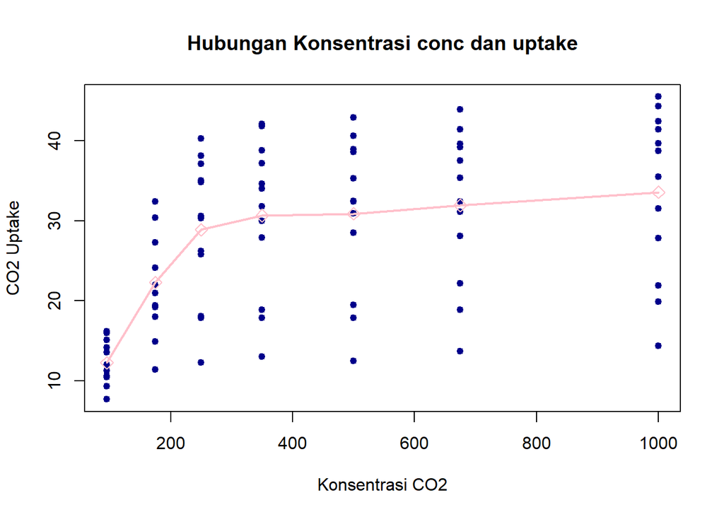

```r
plot(CO2$conc, CO2$uptake,
     main = "Hubungan Konsentrasi conc dan uptake",
     xlab = "Konsentrasi CO2",
     ylab = "CO2 Uptake",
     pch = 20,
     cex = 1.3,
     col = "darkblue",)

mean_uptake <- aggregate(uptake ~ conc, data = CO2, mean)
points(mean_uptake$conc,
       mean_uptake$uptake,
       pch = 23,
       col = "pink",
       cex = 1.3)

lines(mean_uptake$conc,
      mean_uptake$uptake,
      lwd = 2,
      col = "pink")
```

### 2. Grafik berukuran **2 × 2**

Buat satu tampilan grafik berukuran **2 × 2** yang terdiri atas empat jenis visualisasi berbeda untuk mengeksplorasi `conc`, `uptake`, `Type`, dan `Treatment`; tentukan sendiri jenis grafik yang paling sesuai dan berikan judul yang jelas pada setiap grafik.

Penyelesaian

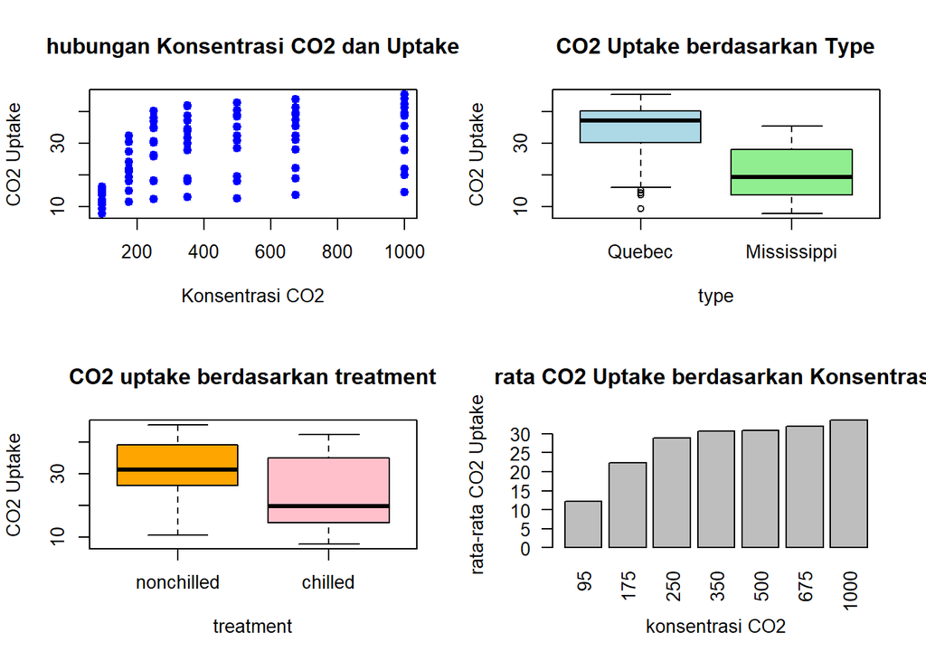

```r
par(mfrow = c(2,2))
mar = c(4,4,3,3)
plot(CO2$conc, CO2$uptake,
     main = "hubungan Konsentrasi CO2 dan Uptake",
     xlab = "Konsentrasi CO2",
     ylab = "CO2 Uptake",
     pch = 19,
     col = "blue")

boxplot(uptake ~ Type,
        data = CO2,
        main = "CO2 Uptake berdasarkan Type",
        xlab = "type",
        ylab = "CO2 Uptake",
        col = c("lightblue", "lightgreen"))


boxplot(uptake ~ Treatment,
        data = CO2,
        main = "CO2 uptake berdasarkan treatment",
        xlab = "treatment",
        ylab = "CO2 Uptake",
        col = c("orange", "pink"))


rata_uptake <- aggregate(uptake ~ conc,
                         data = CO2,
                         FUN = mean)

barplot(rata_uptake$uptake,
        names.arg = rata_uptake$conc,
        main = "rata CO2 Uptake berdasarkan Konsentrasi",
        xlab = "konsentrasi CO2",
        ylab = "rata-rata CO2 Uptake",
        col = "gray",
        las = 2)
```

### 3. qqplot dan ggplot

Gunakan `qplot()` untuk membuat visualisasi cepat hubungan `conc` dan `uptake` berdasarkan `Treatment`, kemudian buat kembali visualisasi tersebut menggunakan `ggplot2` dengan memetakan `Treatment` dan `Type` ke **atribut visual yang berbeda** di dalam `aes()` serta menggunakan `geom_*` yang sesuai.

Penyelesaian

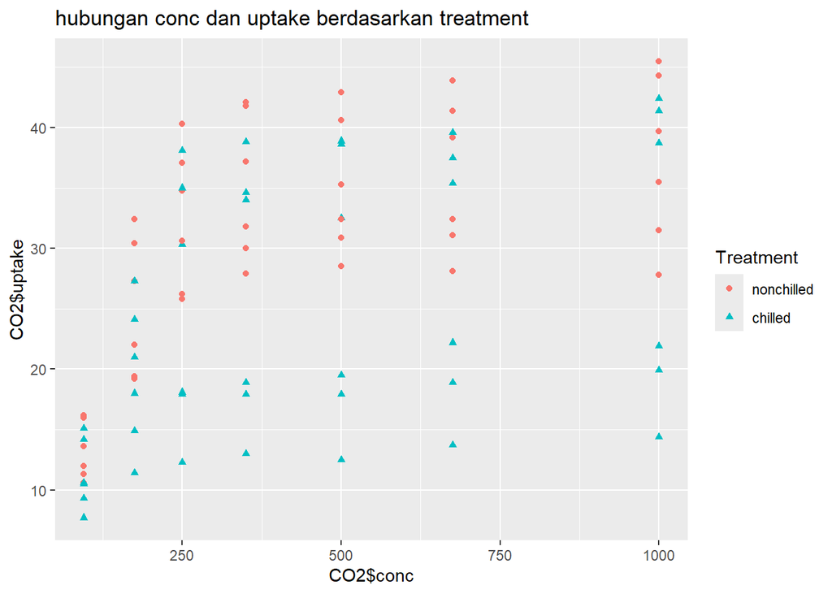

```r
qplot(x = CO2$conc,
     y = CO2$uptake,
     data = CO2,
     col = Treatment,
     shape = Treatment,
     main = "hubungan conc dan uptake berdasarkan treatment")
```

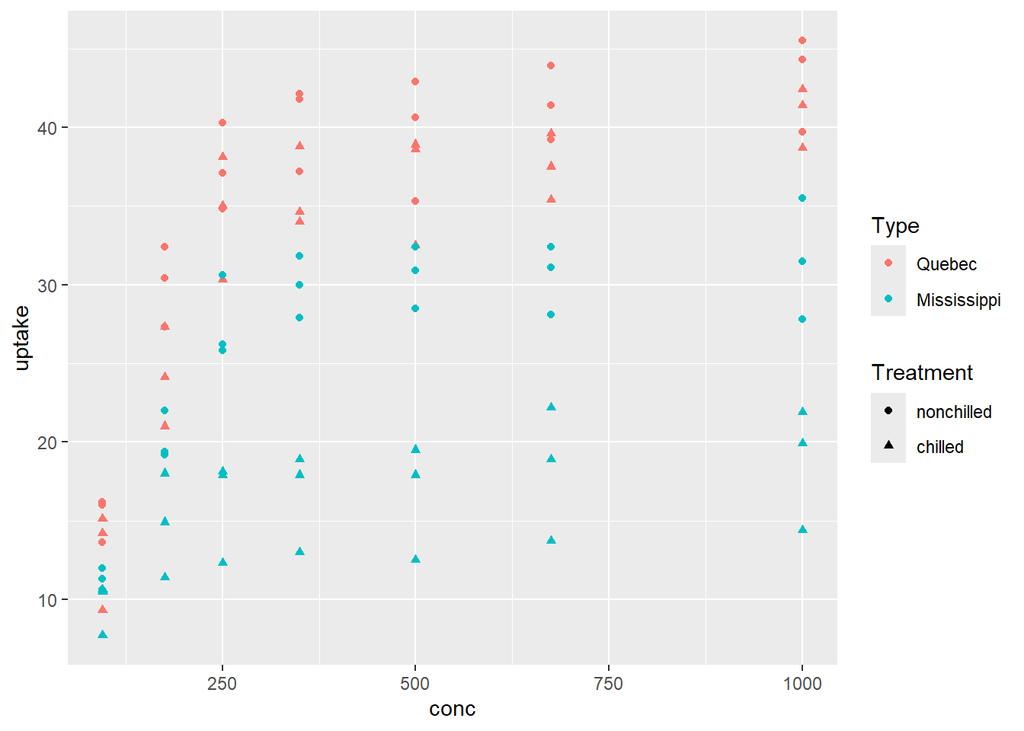

```r
ggplot(data,
  aes(x = conc,
      y = uptake,
      col = Type,
      shape = Treatment)) +
geom_point()
```

### 4. Kembangkan Grafik

Kembangkan grafik `ggplot2` tersebut dengan menambahkan minimal satu `stat_*`, satu `scale_*`, serta salah satu `coord_*`, kemudian lengkapi grafik menggunakan `labs()` dan `theme()` atau salah satu tema siap pakai agar grafik lebih informatif dan mudah dibaca.

Penyelesaian

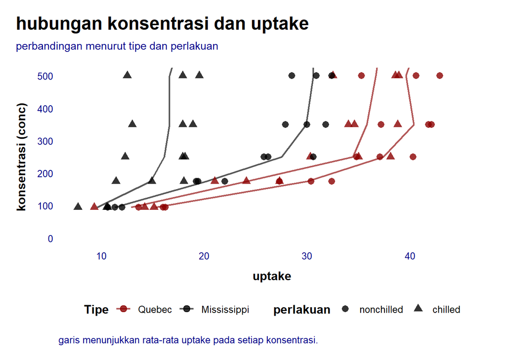

```r
library(ggplot2)

ggplot(data, aes(
  x = conc,
  y = uptake,
  color = Type,
  shape = Treatment
)) +
  stat_summary(
    aes(group = interaction(Type, Treatment)),
    fun = mean,
    geom = "line",
    linewidth = 0.8,
    alpha = 0.65
  ) +
  geom_point(
    size = 2.8,
    alpha = 0.8
  ) +
  scale_color_manual(
    values = c("darkred", "black")
  ) +
  scale_shape_manual(
    values = c(16, 17)
  ) +
  scale_x_continuous(
    breaks = seq(0, 500, 100)
  ) +
  coord_flip(xlim = c(0, 500)) +
  labs(
    title = "hubungan konsentrasi dan uptake",
    subtitle = "perbandingan menurut tipe dan perlakuan",
    x = "konsentrasi (conc)",
    y = "uptake",
    color = "Tipe",
    shape = "perlakuan",
    caption = "garis menunjukkan rata-rata uptake pada setiap konsentrasi."
  ) +
  theme_minimal(base_size = 12) +
  theme(
    plot.title = element_text(
      face = "bold", size = 18, color = "black",
      margin = margin(b = 8)
    ),
    plot.subtitle = element_text(
      size = 11, color = "darkblue",
      margin = margin(b = 16)
    ),
    plot.title.position = "plot",
    axis.title = element_text(face = "bold", color = "black"),
    axis.title.x = element_text(margin = margin(t = 10)),
    axis.title.y = element_text(margin = margin(r = 10)),
    axis.text = element_text(color = "darkblue"),
    panel.grid.minor = element_blank(),
    panel.grid.major = element_line(color = "white"),
    legend.position = "bottom",
    legend.title = element_text(face = "bold"),
    plot.caption = element_text(
      color = "darkblue", hjust = 0,
      margin = margin(t = 12)
    ),
    plot.background = element_rect(fill = "white", color = NA),
    plot.margin = margin(16, 20, 16, 16)
  )
```

Grafik menunjukkan bahwa uptake cenderung meningkat seiring bertambahnya konsentrasi, kemudian relatif stabil pada konsentrasi tinggi. Tipe Quebec umumnya menunjukkan uptake lebih tinggi dibandingkan Mississippi. Perlakuan chilled berkaitan dengan uptake yang lebih rendah, dengan perbedaan yang lebih jelas pada Mississippi dibandingkan Quebec. Pola ini mengindikasikan adanya kemungkinan perbedaan respons terhadap perlakuan antar tipe tanaman. Namun, temuan tersebut bersifat deskriptif; pengujian statistik diperlukan untuk menentukan apakah perbedaan dan interaksi tersebut signifikan.

### 5. Save

Simpan grafik akhir menggunakan `ggsave()` dalam format PNG dengan nama **`co2_uptake_visualisasi.png`**, kemudian tuliskan interpretasi mengenai hubungan antara konsentrasi CO₂ dan `uptake` serta perbedaan pola yang terlihat berdasarkan `Type` dan `Treatment`.

Penyelesaian

```r
ggsave("co2_uptake_visualisasi.png",
       width = 7,
       height = 5,
       dpi = 300)
```